# Environmental Metal Exposure, Nutrition, and Cardiometabolic Biomarkers

A Reproducible Cross-Sectional Analysis of NHANES 2017<80><93>2018

Author

Affiliation

Allen Xu

New York University

Published

April 30, 2026

## Abstract

**Background:** Environmental exposures to heavy metals such as lead, cadmium, and mercury are ubiquitous in the U.S. population and may contribute to cardiometabolic dysregulation. Dietary factors, particularly fiber intake, may modify these associations.

**Methods:** We analyzed data from 5014 U.S. adults aged <89>20 years from the National Health and Nutrition Examination Survey (NHANES) 2017<80><93>2018. Blood lead, cadmium, and total mercury were the primary exposures. HbA1c was the primary continuous outcome; elevated HbA1c (<89>5.7%) was the binary outcome. Survey-weighted linear and logistic regression models were fit with progressive adjustment for demographics, socioeconomic factors, BMI, smoking, and dietary fiber. An interaction term (blood lead <97> dietary fiber) was evaluated.

**Results:** The analytic sample comprised 5014 participants (weighted to represent approximately 177 million U.S. adults). Geometric mean blood lead was 0.96 g/dL. In fully adjusted models, each 1-unit increase in log-transformed blood lead was associated with a = -0.214 (95% CI: -0.277, -0.15) change in HbA1c (%). Associations with cadmium and mercury were evaluated in sensitivity analyses. The interaction term for lead <97> dietary fiber was assessed.

**Keywords:** heavy metals, blood lead, HbA1c, glycated hemoglobin, dietary fiber, NHANES, cardiometabolic, epidemiology, survey methods

## 1 Background

Heavy metal exposures<80><94>lead, cadmium, and mercury<80><94>remain pervasive environmental health concerns in the United States, despite decades of regulatory efforts. Even at low levels, these metals may disrupt endocrine function, promote oxidative stress, and impair mitochondrial function <80><94> mechanistic pathways that have been proposed in the toxicology and clinical literature as routes from low-level metal exposure to insulin resistance and cardiometabolic disease.

**Lead** is a known neurotoxicant, but a substantial body of population-based evidence has also linked low-level lead exposure to hypertension, impaired glucose metabolism, and cardiovascular mortality. **Cadmium** accumulates in the kidney and has been associated with diabetes and chronic kidney disease at concentrations well below occupational thresholds. **Mercury**, particularly inorganic and methylmercury species, has been associated in some studies with oxidative damage, endothelial dysfunction, and metabolic disturbance.

Diet is a key modulator of metal bioavailability and toxicity. Dietary fiber, calcium, iron, and vitamin C have been reported to reduce gastrointestinal absorption of lead and cadmium, and antioxidant nutrients may buffer oxidative damage from metal exposures. Whether dietary quality modifies the population-level association between metal exposures and cardiometabolic biomarkers remains underexplored.

HbA1c (glycated hemoglobin) is an established biomarker of average glycemia over the preceding 2<80><93>3 months and a clinical diagnostic criterion for prediabetes (<89>5.7%) and diabetes (<89>6.5%). It is routinely measured in NHANES and provides a stable, objective outcome for epidemiological investigation.

## 2 Research Question

> *Are blood metal exposures (lead, cadmium, mercury) associated with HbA1c and dysglycemia status among U.S. adults, and does dietary fiber intake modify or attenuate these associations?*

## 3 Data Source

This analysis uses publicly available data from the **National Health and Nutrition Examination Survey (NHANES)**, a continuous cross-sectional survey conducted by the National Center for Health Statistics (NCHS) of the U.S. Centers for Disease Control and Prevention (CDC). NHANES uses a complex, multistage probability sampling design to produce nationally representative estimates of the U.S. civilian, non-institutionalized population.

We used the **NHANES 2017<80><93>2018** cycle:

| Cycle | Suffix | N (all ages) | Weight Variable |
| --- | --- | --- | --- |
| 2017<80><93>2018 | `_J` | 9,254 | `WTMEC2YR` |

Data files were downloaded directly from the CDC NHANES public repository. All data files are available at: https://wwwn.cdc.gov/nchs/nhanes/.

## 4 Study Population

Table 1: Exclusion Flow <80><94> Derivation of Analytic Sample

| Exclusion Step | Remaining N | Excluded N |
| --- | --- | --- |
| Full NHANES 2017-2018 sample | 9,254 | 0 |
| Restrict to adults aged 20 | 5,569 | 3,685 |
| Exclude zero/missing MEC exam weight | 5,265 | 304 |
| Exclude missing all three metal exposures | 5,021 | 244 |
| Exclude missing HbA1c (primary outcome) | 5,014 | 7 |
| Exclude missing age, sex, or race/ethnicity | 5,014 | 0 |

The final analytic sample comprised **5,014** U.S. adults aged <89>20 years with available blood metal and HbA1c measurements across NHANES 2017<80><93>2018.

## 5 Variables

### 5.1 Exposures: Blood Metal Concentrations

Blood metals were measured by the NHANES Mobile Examination Center (MEC) using inductively coupled plasma<80><93>mass spectrometry (ICP-MS) on venous blood samples (PBCD files). Three exposures were analyzed:

| Variable | NHANES Name | Unit | File |
| --- | --- | --- | --- |
| Blood lead | `LBXBPB` | g/dL | PBCD_J |
| Blood cadmium | `LBXBCD` | g/dL | PBCD_J |
| Blood total mercury | `LBXTHG` | g/L | PBCD_J |

All exposures were **log-transformed** (natural log) prior to analysis to reduce right skewness and facilitate interpretation of a one-unit change on the log scale as a multiplicative effect on the original scale. Values <89>0 were set to missing (<0.01% of observations).

### 5.2 Primary Outcome: HbA1c

Glycated hemoglobin A1c (HbA1c, %) was measured via high-performance liquid chromatography (HPLC) from venous blood specimens (GHB files). A binary outcome was defined as **elevated HbA1c <89>5.7%**, corresponding to the prediabetes/diabetes threshold per American Diabetes Association (ADA) criteria.

### 5.3 Effect Modifier / Confounder: Dietary Fiber

Dietary fiber (g/day) was derived from the **Day 1 24-hour dietary recall** (DR1TOT files). Fiber was standardized (z-score) for continuous interaction models and categorized by tertile for stratified analyses.

### 5.4 Covariates

| Variable | NHANES Name | Coding |
| --- | --- | --- |
| Age (years) | `RIDAGEYR` | Continuous; categorical (20<80><93>39, 40<80><93>59, <89>60) |
| Sex | `RIAGENDR` | Male / Female |
| Race/ethnicity | `RIDRETH3` | 6-level factor |
| Education | `DMDEDUC2` | 5-level factor (adults <89>20) |
| Poverty-income ratio | `INDFMPIR` | Continuous (top-coded at 5) |
| BMI (kg/m) | `BMXBMI` | Continuous; categorical (WHO) |
| Smoking status | `SMQ020`, `SMQ040` | Never / Former / Current |

## 6 Methods

### 6.1 Statistical Approach

All analyses were conducted in **R** (version <89>4.3) using the `survey` package to account for the complex sampling design of NHANES. Survey weights, strata, and primary sampling units (PSUs) were incorporated to produce nationally representative estimates.

**Survey weight:** The 2-year MEC examination weight (`WTMEC2YR`) was used directly, as this analysis covers a single NHANES cycle (2017<80><93>2018), per NCHS analytic guidelines.

**Regression models:** Four sequential models were fit for the primary analysis (log blood lead <86><92> HbA1c):

- **Model 1 (Unadjusted):** `HbA1c ~ log(blood lead)`
- **Model 2 (Demographic):** `+ age + sex + race/ethnicity`
- **Model 3 (Fully adjusted):** `+ education + poverty-income ratio + BMI + smoking + dietary fiber`
- **Model 4 (Interaction):** `Model 3 + log(blood lead) <c3><97> dietary fiber (z-score)`

**Binary outcome:** Logistic regression (survey-weighted, quasi-binomial family) was used for elevated HbA1c (<89>5.7%) following the same model sequence.

**Sensitivity analyses:** Models 1<80><93>3 were repeated substituting blood cadmium and blood mercury for blood lead.

**Missing data:** Complete-case analysis was used. Proportion missing for each variable is reported in Table 5.

### 6.2 Software

Table 2: Key R Packages

| Package | Purpose | Version |
| --- | --- | --- |
| survey | Survey-weighted regression | 4.1.1 |
| srvyr | Tidyverse-style survey wrappers | 1.2.0 |
| gtsummary | Publication tables | 1.7.1 |
| ggplot2 | Data visualization | 3.4.2 |
| tidyverse | Data wrangling | 2.0.0 |
| haven | Read NHANES XPT files (paired with curl for direct CDC download) | 2.5.2 |
| broom | Tidy model output | 1.0.4 |

## 7 Results

### 7.1 Sample Characteristics

Table 3: Table 1. Characteristics of Analytic Sample (NHANES 2017<80><93>2018)

| **Characteristic** | **N** | **N = 5,014**<sup>1</sup> |
| --- | --- | --- |
| Age (years) | 5,014 | 51.5 (17.7) |
| Sex | 5,014 |  |
| Male |  | 2,414 (48%) |
| Female |  | 2,600 (52%) |
| Race/ethnicity | 5,014 |  |
| Mexican American |  | 682 (14%) |
| Other Hispanic |  | 479 (9.6%) |
| Non-Hispanic White |  | 1,746 (35%) |
| Non-Hispanic Black |  | 1,146 (23%) |
| Non-Hispanic Asian |  | 708 (14%) |
| Other/Multiracial |  | 253 (5.0%) |
| Education | 5,003 |  |
| Less than 9th grade |  | 430 (8.6%) |
| 9-11th grade |  | 572 (11%) |
| High school/GED |  | 1,195 (24%) |
| Some college/AA |  | 1,621 (32%) |
| College graduate+ |  | 1,185 (24%) |
| Missing |  | 11 |
| Poverty-income ratio category | 4,361 |  |
| <1 (Below poverty) |  | 803 (18%) |
| 1-<2 |  | 1,246 (29%) |
| 2-<3 |  | 713 (16%) |
| <e2><89><a5>3 |  | 1,599 (37%) |
| Missing |  | 653 |
| Smoking status | 5,014 |  |
| Never |  | 2,899 (58%) |
| Former |  | 1,210 (24%) |
| Current |  | 905 (18%) |
| BMI (kg/m<c2><b2>) | 4,937 | 29.9 (7.4) |
| Missing |  | 77 |
| Blood lead (<c2><b5>g/dL) | 5,014 | 1.3 (1.4) |
| Blood cadmium (<c2><b5>g/dL) | 5,014 | 0.5 (0.6) |
| Blood total mercury (<c2><b5>g/L) | 5,014 | 1.5 (2.7) |
| HbA1c (%) | 5,014 | 5.9 (1.1) |
| Elevated HbA1c (<e2><89><a5>5.7%) | 5,014 | 2,294 (46%) |
| Dietary fiber (g/day) | 4,557 | 16.8 (10.9) |
| Missing |  | 457 |
| Energy intake (kcal/day) | 4,557 | 2,112.2 (1,035.6) |
| Missing |  | 457 |

<sup>1</sup> Mean (SD); n (%)

Table 4: Table 1b. Sample Characteristics by Blood Lead Quartile

| **Characteristic** | **Blood Lead Quartile** **Overall**, N = 5,014<sup>1</sup> | **Blood Lead Quartile** **Q1**, N = 1,287<sup>1</sup> | **Blood Lead Quartile** **Q2**, N = 1,239<sup>1</sup> | **Blood Lead Quartile** **Q3**, N = 1,235<sup>1</sup> | **Blood Lead Quartile** **Q4**, N = 1,253<sup>1</sup> | **p-value**<sup>2</sup> |  |
| --- | --- | --- | --- | --- | --- | --- | --- |
| Age (years) | 51.5 (17.7) | 39.6 (15.3) | 50.2 (16.9) | 56.2 (15.6) | 60.5 (15.4) |  | <0.001 |
| Sex |  |  |  |  |  | <0.001 |  |
| Male | 2,414 (48%) | 430 (33%) | 586 (47%) | 633 (51%) | 765 (61%) |  |  |
| Female | 2,600 (52%) | 857 (67%) | 653 (53%) | 602 (49%) | 488 (39%) |  |  |
| Race/ethnicity |  |  |  |  |  | <0.001 |  |
| Mexican American | 682 (14%) | 200 (16%) | 175 (14%) | 166 (13%) | 141 (11%) |  |  |
| Other Hispanic | 479 (9.6%) | 199 (15%) | 123 (9.9%) | 102 (8.3%) | 55 (4.4%) |  |  |
| Non-Hispanic White | 1,746 (35%) | 442 (34%) | 414 (33%) | 436 (35%) | 454 (36%) |  |  |
| Non-Hispanic Black | 1,146 (23%) | 285 (22%) | 290 (23%) | 247 (20%) | 324 (26%) |  |  |
| Non-Hispanic Asian | 708 (14%) | 90 (7.0%) | 178 (14%) | 217 (18%) | 223 (18%) |  |  |
| Other/Multiracial | 253 (5.0%) | 71 (5.5%) | 59 (4.8%) | 67 (5.4%) | 56 (4.5%) |  |  |
| Education |  |  |  |  |  | <0.001 |  |
| Less than 9th grade | 430 (8.6%) | 94 (7.3%) | 96 (7.8%) | 104 (8.4%) | 136 (11%) |  |  |
| 9-11th grade | 572 (11%) | 106 (8.2%) | 122 (9.9%) | 150 (12%) | 194 (16%) |  |  |
| High school/GED | 1,195 (24%) | 292 (23%) | 275 (22%) | 308 (25%) | 320 (26%) |  |  |
| Some college/AA | 1,621 (32%) | 510 (40%) | 402 (33%) | 363 (29%) | 346 (28%) |  |  |
| College graduate+ | 1,185 (24%) | 285 (22%) | 339 (27%) | 306 (25%) | 255 (20%) |  |  |
| Poverty-income ratio category |  |  |  |  |  | 0.016 |  |
| <1 (Below poverty) | 803 (18%) | 197 (17%) | 184 (17%) | 201 (19%) | 221 (20%) |  |  |
| 1-<2 | 1,246 (29%) | 315 (28%) | 297 (28%) | 299 (28%) | 335 (31%) |  |  |
| 2-<3 | 713 (16%) | 201 (18%) | 159 (15%) | 178 (17%) | 175 (16%) |  |  |
| <e2><89><a5>3 | 1,599 (37%) | 424 (37%) | 437 (41%) | 388 (36%) | 350 (32%) |  |  |
| Smoking status |  |  |  |  |  | <0.001 |  |
| Never | 2,899 (58%) | 935 (73%) | 723 (58%) | 674 (55%) | 567 (45%) |  |  |
| Former | 1,210 (24%) | 215 (17%) | 305 (25%) | 314 (25%) | 376 (30%) |  |  |
| Current | 905 (18%) | 137 (11%) | 211 (17%) | 247 (20%) | 310 (25%) |  |  |
| BMI (kg/m<c2><b2>) | 29.9 (7.4) | 31.5 (8.8) | 30.2 (7.3) | 29.6 (6.6) | 28.1 (6.1) | <0.001 |  |
| HbA1c (%) | 5.9 (1.1) | 5.8 (1.2) | 5.9 (1.1) | 6.0 (1.1) | 5.9 (0.9) | <0.001 |  |
| Elevated HbA1c (<e2><89><a5>5.7%) | 2,294 (46%) | 436 (34%) | 572 (46%) | 646 (52%) | 640 (51%) | <0.001 |  |
| Dietary fiber (g/day) | 16.8 (10.9) | 16.7 (10.5) | 16.6 (10.7) | 16.9 (10.8) | 17.1 (11.8) | 0.8 |  |
| Energy intake (kcal/day) | 2,112.2 (1,035.6) | 2,194.0 (1,096.7) | 2,104.7 (1,001.6) | 2,070.3 (990.4) | 2,075.1 (1,043.8) | 0.006 |  |

<sup>1</sup> Mean (SD); n (%)  
<sup>2</sup> Kruskal-Wallis rank sum test; Pearson’s Chi-squared test

### 7.2 Missingness

Table 5: Missingness Summary for Key Analysis Variables

| Variable | N Missing | % Missing | N Complete |
| --- | --- | --- | --- |
| pir | 653 | 13.0 | 4,361 |
| fiber_g | 457 | 9.1 | 4,557 |
| vitc_mg | 457 | 9.1 | 4,557 |
| energy_kcal | 457 | 9.1 | 4,557 |
| dbp | 253 | 5.0 | 4,761 |
| sbp | 239 | 4.8 | 4,775 |
| crp | 111 | 2.2 | 4,903 |
| total_chol | 83 | 1.7 | 4,931 |
| hdl_chol | 83 | 1.7 | 4,931 |
| bmi | 77 | 1.5 | 4,937 |
| educ | 11 | 0.2 | 5,003 |
| blood_lead | 0 | 0.0 | 5,014 |
| blood_cad | 0 | 0.0 | 5,014 |
| blood_hg | 0 | 0.0 | 5,014 |
| hba1c | 0 | 0.0 | 5,014 |
| smoke_status | 0 | 0.0 | 5,014 |

### 7.3 Exposure Distributions

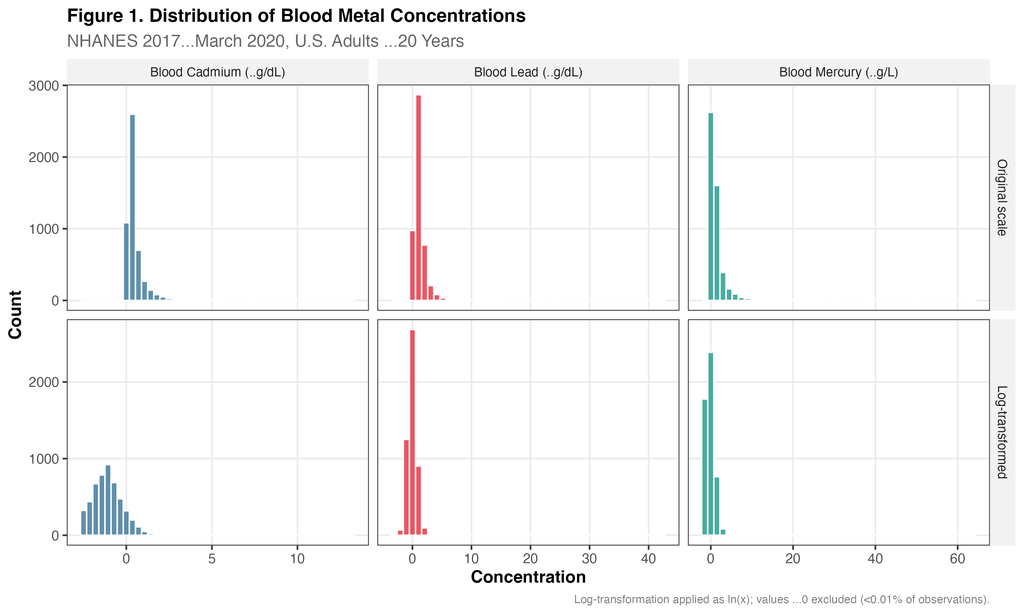

Figure 1: Figure 1. Distribution of Blood Metal Concentrations (Raw and Log-Transformed)

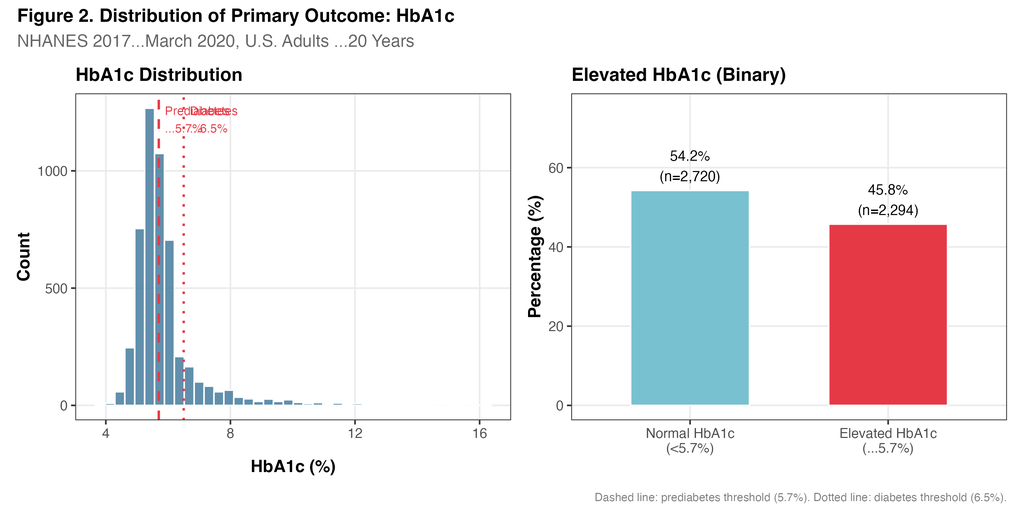

Figure 2: Figure 2. Distribution of Primary Outcome: HbA1c

### 7.4 Exposure<80><93>Outcome Relationship

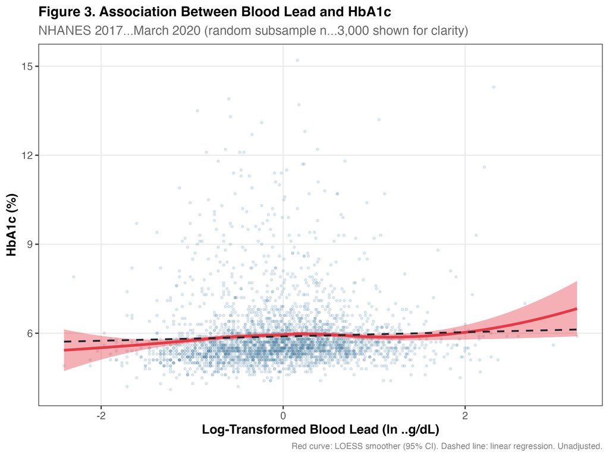

Figure 3: Figure 3. Scatter Plot: Log Blood Lead vs. HbA1c (LOESS and Linear Fit)

### 7.5 Regression Results

#### 7.5.1 Linear Regression: Blood Lead <86><92> HbA1c

Table 6: Table 2. Association of Log Blood Lead with HbA1c (%) <80><94> Survey-Weighted Linear Regression

| Model | <ce><b2> (95% CI) | Std. Error | p-value |
| --- | --- | --- | --- |
| Model 1: Unadjusted | 0.042 (-0.008, 0.092) | 0.0234 | 0.094 |
| Model 2: Demo-adjusted | -0.224 (-0.295, -0.152) | 0.0301 | <0.001 |
| Model 3: Fully adjusted | -0.214 (-0.277, -0.15) | 0.0299 | <0.001 |
| Model 4: + Lead<c3><97>Fiber interaction | -0.213 (-0.279, -0.147) | 0.0308 | <0.001 |

Note:  
<ce><b2> = change in HbA1c (%) per 1-unit increase in ln(blood lead, <c2><b5>g/dL). Model 1: Unadjusted. Model 2: + age, sex, race/ethnicity. Model 3: + education, PIR, BMI, smoking, dietary fiber. Model 4: Model 3 + lead<c3><97>fiber interaction.

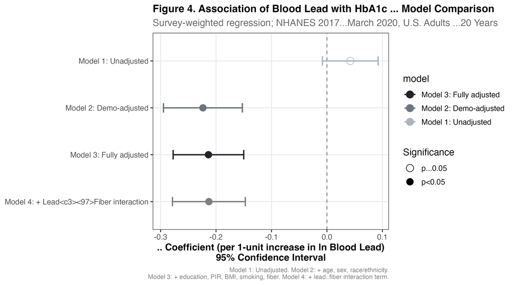

Figure 4: Figure 4. Forest Plot: Association of Blood Lead with HbA1c Across Models

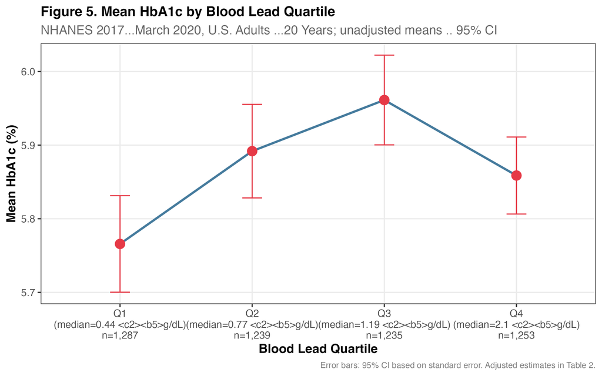

Figure 5: Figure 5. Mean HbA1c by Blood Lead Quartile

#### 7.5.2 Logistic Regression: Blood Lead <86><92> Elevated HbA1c (<89>5.7%)

Table 7: Table 3. Association of Log Blood Lead with Elevated HbA1c (<89>5.7%) <80><94> Survey-Weighted Logistic Regression

| Model | OR (95% CI) | p-value |
| --- | --- | --- |
| Model 1: Unadjusted | 1.362 (1.184, 1.567) | <0.001 |
| Model 2: Demo-adjusted | 0.596 (0.495, 0.718) | <0.001 |
| Model 3: Fully adjusted | 0.626 (0.523, 0.748) | <0.001 |

Note:  
OR = odds ratio per 1-unit increase in ln(blood lead, <c2><b5>g/dL). Outcome: HbA1c <e2><89><a5>5.7% (prediabetes/diabetes threshold). Models adjusted as in Table 2.

#### 7.5.3 Interaction: Blood Lead <97> Dietary Fiber

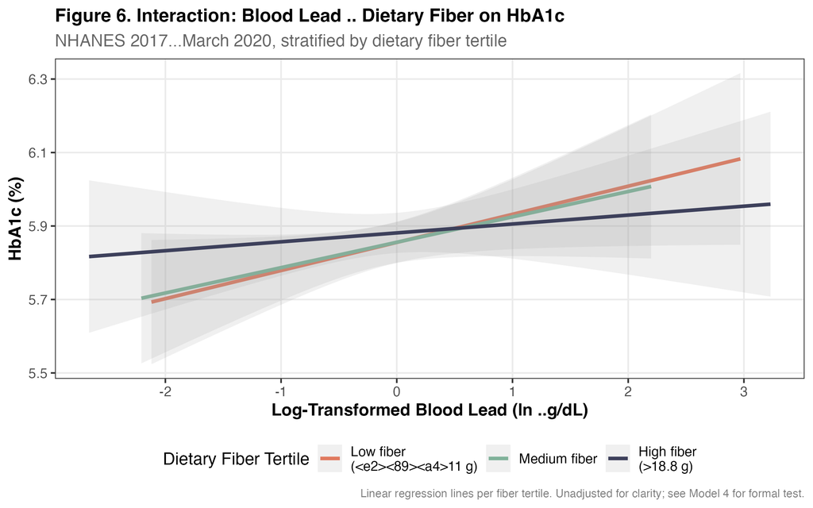

Figure 6: Figure 6. Interaction: Blood Lead <97> Dietary Fiber on HbA1c

The interaction term (log blood lead <97> dietary fiber z-score) had a coefficient of = -0.0239 (p = 0.284), suggesting no statistically significant modification of the lead-HbA1c association by dietary fiber intake..

#### 7.5.4 Sensitivity Analyses: All Metals

Table 8: Table 4. Sensitivity Analysis: Association of All Blood Metals with HbA1c (Fully Adjusted)

| Exposure | <ce><b2> (95% CI) | p-value |
| --- | --- | --- |
| Blood cadmium | -0.046 (-0.114, 0.022) | 0.169 |
| Blood mercury | -0.029 (-0.05, -0.008) | 0.011 |
| Blood lead | -0.214 (-0.277, -0.15) | <0.001 |

Note:  
All models adjusted for age, sex, race/ethnicity, education, PIR, BMI, smoking, dietary fiber. Survey-weighted.

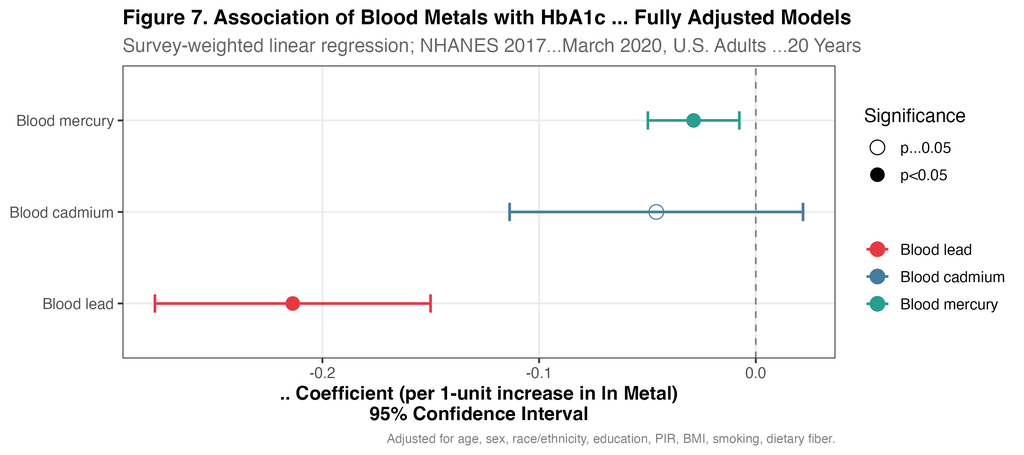

Figure 7: Figure 7. Multi-Metal Comparison: Fully Adjusted Associations with HbA1c

## 8 Interpretation

These findings contribute to the cross-sectional literature on environmental metal exposures and glycemic biomarkers in U.S. adults. In this sample, the unadjusted association between log blood lead and HbA1c was small and not statistically significant, while the fully adjusted association was inverse and statistically significant. **This pattern should not be read as evidence of a protective effect of lead.** It is more consistent with negative confounding by demographic and socioeconomic factors that are independently associated with both blood-lead burden and glycemic control, possibly compounded by selection processes, the timing window captured by blood-lead measurement (recent rather than cumulative exposure), and model specification under residual confounding.

Prior NHANES analyses have reported positive associations between metal exposures and dysglycemia under different exposure metrics, study periods, or modeling choices. The contrast with the present adjusted estimate underscores that observational associations between long-term metal burden and glycemia are sensitive to confounding structure and are not consistently reproducible across analytic decisions. Mechanistic claims (-cell damage, oxidative stress) come from experimental and clinical literatures and cannot be evaluated with these data.

The lead <97> dietary-fiber interaction was examined to assess whether dietary quality modifies the lead<80><93>HbA1c association at the population level. Any modification observed should likewise be interpreted as a statistical interaction in an observational dataset, not a demonstration that fiber buffers the toxicokinetic effect of lead.

## 10 Reproducibility Statement

This analysis is fully reproducible from publicly available data. All R code is in the `R/` directory and can be executed in sequence (scripts 00<80><93>07) using the `here` package for portable file paths. Raw NHANES `.XPT` files are downloaded directly from the CDC public data repository via `curl` and `haven::read_xpt()`. The analytic dataset is saved as `data/processed/analysis_dataset_v2.rds`. This report is rendered using Quarto from `report/nhanes_metal_nutrition_biomarkers.qmd`. The full pipeline can be run end-to-end with `Rscript run_all.R`.

**To reproduce:**

```bash
Rscript R/00_setup.R
Rscript R/01_download_data.R
Rscript R/02_clean_merge_data.R
Rscript R/03_define_variables.R
Rscript R/04_descriptive_analysis.R
Rscript R/05_regression_models.R
Rscript R/06_visualizations.R
Rscript R/07_export_tables_figures.R
quarto render report/nhanes_metal_nutrition_biomarkers.qmd
```

## 11 Future Extensions

1. **Mixture analysis (WQS, BKMR):** Model the joint effect of metal mixtures rather than individual exposures, accounting for correlations between co-occurring metals.
2. **Mediation analysis:** Examine whether BMI mediates the metal-HbA1c pathway, using mediation packages such as `mediation` or `CMAverse`.
3. **Subgroup analyses:** Stratify by race/ethnicity and sex to investigate health disparities in metal-metabolic associations.
4. **Longitudinal validation:** Link NHANES findings to longitudinal cohort data (e.g., ARIC, Strong Heart Study) to test temporality.
5. **Additional outcomes:** Extend to CRP (inflammatory biomarker), kidney function (eGFR, albuminuria), and lipid profiles.
6. **Dietary pattern analysis:** Replace single nutrients with overall dietary patterns (e.g., Healthy Eating Index) as more comprehensive nutrition covariates.